# Assessing progression independent of relapse activity (PIRA) in MS

- No relapses during the 90 days before and 30 days after the event, and during the 90 days before and 30 days after confirmation [6]:

  ```r
  relapse_indep <- relapse_indep_from_bounds(p0=0, p1=0,   # baseline
                                            e0=90, e1=30, # event
                                            c0=90, c1=30) # confirmation
  ```

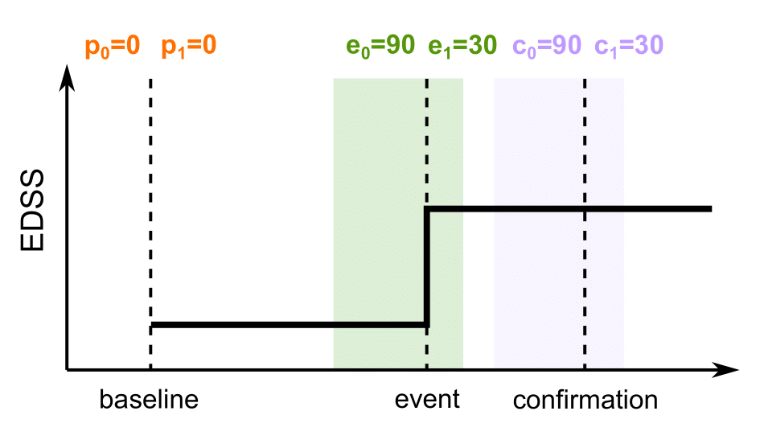

  *Figure 2. Relapse-free intervals as recommended in [6].*

- No relapses in the whole period between reference and confirmation [6]:

  ```r
  relapse_indep <- relapse_indep_from_bounds(p0=0, p1=NULL,    # baseline
                                            e0=NULL, e1=NULL, # event
                                            c0=NULL, c1=0)    # confirmation
  ```

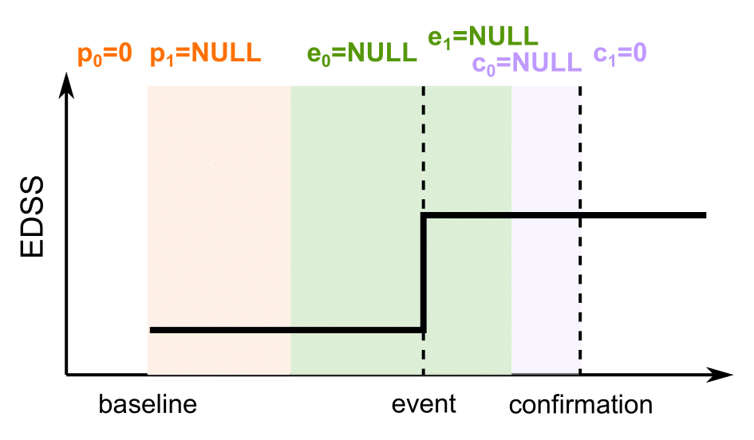

  *Figure 3. Relapse-free intervals as recommended in [6] for high specificity.*

- No relapses between the reference visit and 30 days after the event, and during the 30 days before and 30 days after confirmation [4]:

  ```r
  relapse_indep <- relapse_indep_from_bounds(p0=0, p1=NULL,  # baseline
                                            e0=NULL, e1=30, # event
                                            c0=30, c1=30)   # confirmation
  ```

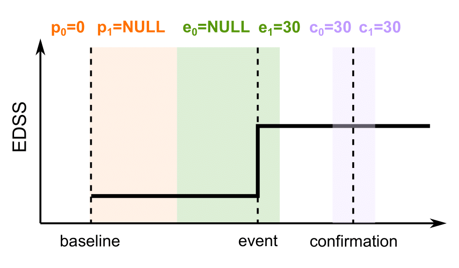

  *Figure 4. Relapse-free intervals as used in [4].*

- No relapses during the 90 days before the event and between the event and the confirmation visit [5]:

  ```r
  relapse_indep <- relapse_indep_from_bounds(p0=0, p1=0,     # baseline
                                            e0=90, e1=NULL, # event
                                            c0=NULL, c1=0)  # confirmation
  ```

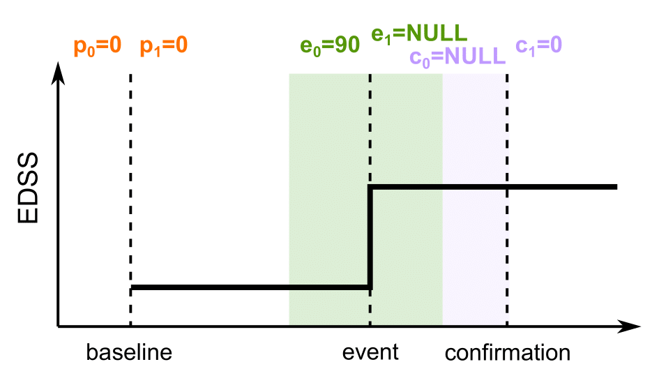

  *Figure 5. Relapse-free intervals as used in [5].*

- No relapses since the last visit preceding the event (up to the event) [7]:

  ```r
  relapse_indep <- relapse_indep_from_bounds(p0=0, p1=NULL,      # last visit before the event
                                            e0=NULL, e1=0, # event
                                            prec_type='last')
  ```

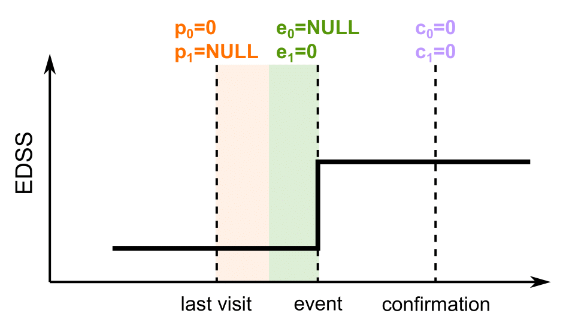

  *Figure 6. Relapse-free intervals as recommended in [7].*

The requirement of relapse-free periods is often coupled with a non-fixed baseline scheme. This can be a roving baseline, where the reference value is updated after every confirmed improvement or worsening event, as in [6] (`baseline='roving'` in `MSprog()`); or a re-baseline after the onset of each relapse, as in [4] (`relapse_rebl=TRUE` in `MSprog()`); or both, as in [7].